# Part II - Explanatory Analysis of Prosper Loan Data

## By: Morris Muchiri Mugo

## Investigation Overview

In the **Bivariate Plots** from the time series I observed that the `Borrower rate` has been increasing from 2009 till 2011 then it started to fall and the `monthly income` of people taking loans has been increasing over the years. I also observed that the majority of people who their `loan status` was either `current` or `completed` most were home owners and also their `Borrower rate` was lower than the rest. There was also a ngative correlation between the `Borrower rate` and `Monthly loan payment` and there was a positive correlation between `Debt to income ratio` and `Borrower rate`.

## Dataset Overview

This data set contains 75,233 loans with 22 variables on each loan, including loan amount, borrower rate (or interest rate), current loan status, borrower income, and many others.

## (Visualization 1)

The visualization shows the distribution of `Prosper Rating` of loans with **AA** having the least amount while **C** having the majority.

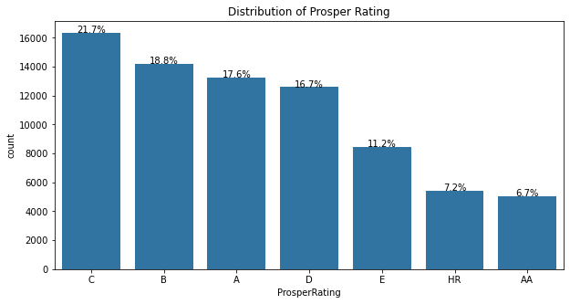

## (Visualization 2)

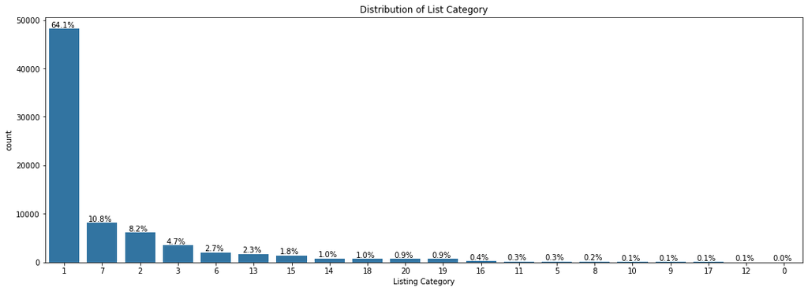

## (Visualization 3)

The visualization shows the distribution of `Employment Status` of people who have taken loans with the majority being **Employed**

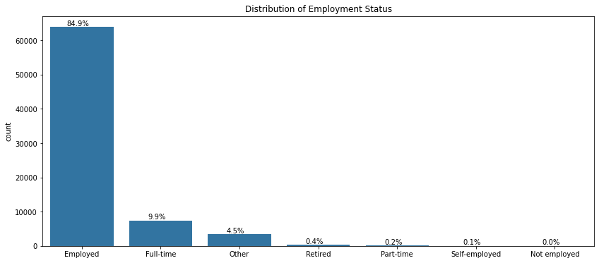

## (Visualization 4)

The visualization shows the distribution of `Loan Status` of people who have taken loans with the majority having **Current** followed by **Completed**

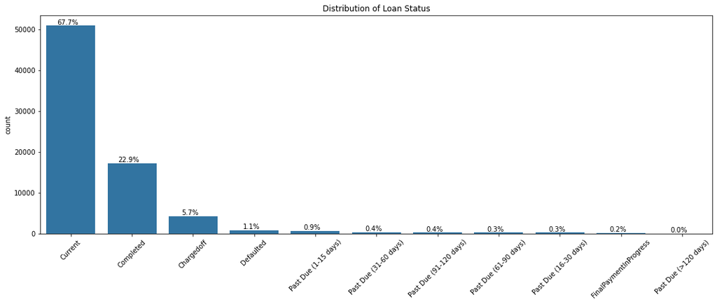

## (Visualization 5)

The visualization shows the distribution of `Stated Monthly Income` of people who have taken loans with the highest Income being **between 4,000 and 6,000**

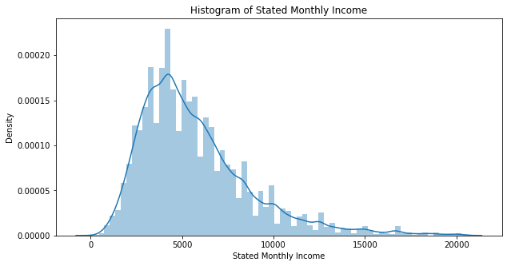

## (Visualization 6)

The visualization shows the time series of `Borrower Rate` based on the Loan Start date and we can see that the Borrower Rate has been increasing from the year **2009** till **2011** when it started to fall

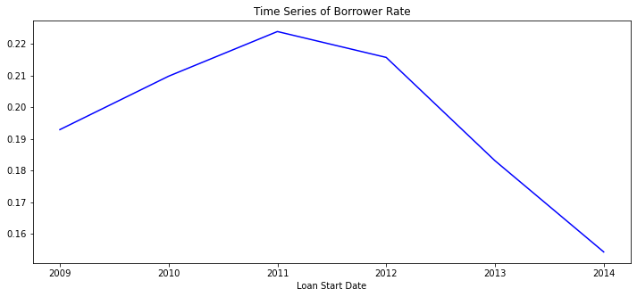